# MEC-Cox implementation

This manual follows **Steps 1–6 of Supplement S2.4, “Computation of the MEC-Cox Estimator via the Dual Newton Solver,”** in the same order and with the same notation. Each step retains the supplement’s derivation and is followed by the corresponding R code. The default example uses the package’s simulated data, logistic regression for source propensity, Cox regression for control survival, and the Kullback–Leibler (KL) generator. Steps 1 and 2 also provide executable RSF and machine-learning alternatives. The general generator notation from the supplement is retained.

[R Markdown source](https://github.com/yain22/mecCox/blob/main/docs/mec-cox-implementation.Rmd) · [Package repository](https://github.com/yain22/mecCox)

## 1. Data and notation

### 1-1. Problem setting

We combine a **treated target cohort** with an **external-control cohort**, such as controls from a historical trial or another data source. For subject $i$, the indicator $A_i=1$ identifies a treated-cohort member receiving the treatment of interest, whereas $A_i=0$ identifies an external-control member receiving control. Source membership and treatment status therefore coincide in this setting. The two cohorts can differ in their baseline covariates $X_i$, including characteristics that predict survival.

Let $T_i^a$ be the potential event time under treatment regime $a$, with $a=1$ denoting treatment and $a=0$ denoting control. The target comparison is between $T_i^1\mid A_i=1$ and $T_i^0\mid A_i=1$: the survival experience of the treated target population under each regime. For a treated subject, the control potential event time is unobserved. External controls contribute information about control survival through their observed follow-up. With $T_i$ denoting the event time under the treatment actually received and $C_i$ the censoring time, each subject contributes $Y_i=\min(T_i,C_i)$ and $\delta_i=I(T_i\le C_i)$.

Write $S_1^a(t)=\Pr(T_i^a>t\mid A_i=1)$ for marginal survival under regime $a$ in the treated target population, and let $\lambda_1^a(t)$ be the corresponding marginal hazard. The subscript $1$ identifies the target population; the superscript $a$ identifies the treatment regime. Under the paper’s marginal proportional hazards model,
$$\lambda_1^a(t)=\lambda_1^0(t)\exp(\theta_{ATT}a),
\qquad a=0,1,$$
the parameter of interest is the ATT marginal hazard ratio
$$HR_{ATT}=\frac{\lambda_1^1(t)}{\lambda_1^0(t)}
=\exp(\theta_{ATT}).$$
Both hazards refer to the treated target population. Under the inverse-probability-weighted Cox regression framework, MEC-Cox estimates this comparison by retaining treated subjects with weight one and calibrating the analysis weights of the external controls.

Figure 1 shows the treated-population comparison and how cross-fitted propensity scores and control-survival features enter the MEC-Cox weighting and estimation steps.

[figure not shown]

**Figure 1. Target comparison and MEC-Cox computation.** The green and orange circles represent the same treated target population ($A_i=1$) under treatment and control, respectively; the purple circle represents the external-control population ($A_i=0$). Here $A_i$ identifies both cohort membership and received treatment, $X_i$ denotes baseline covariates, and $T_i^a$ is the potential event time under regime $a$. The treated cohort’s control outcome $T_i^0$ is counterfactual. Observed follow-up is $Y_i=\min(T_i,C_i)$ with event indicator $\delta_i=I(T_i\le C_i)$, where $T_i$ is the event time under the received treatment and $C_i$ is the censoring time.

The upper box fits the source propensity $\pi(X_i)=\Pr(A_i=1\mid X_i)$ using both cohorts in training set $\mathcal J^{(-k)}$ and predicts $\widehat\pi_i$ for subjects held out in fold $\mathcal J^{(k)}$. Its downward arrow supplies baseline ATT odds weights $\widehat d_i$, normalized so that external-control weights sum to the treated-cohort size. The lower-right box fits control survival on training-fold external controls and constructs held-out feature vectors $\widehat h_i$ for subjects in both cohorts. These vectors contain an intercept and predicted control survival at the landmark times. In the central box, $H_0$ contains external-control feature rows and $T_H=\sum_{i\in\mathcal I_1}\widehat h_i$ is their target total over treated subjects, with $\mathcal I_1=\{i:A_i=1\}$. Bregman calibration imposes $H_0^\top w=T_H$ on the external-control weight vector $w$; its dual residual equation $F(\lambda)=0$ is solved by Newton iteration to obtain $\widehat\lambda$ and calibrated weights $\widehat w_i$.

The horizontal arrows show the reweighting of external controls to represent target control survival under the stated identification assumptions; the dashed arrow supplies the treated-cohort feature totals. External controls retain their observed follow-up and event indicators. The final weighted Cox fit uses weight one for treated subjects and $\widehat w_i$ for external controls. Under the stated marginal proportional hazards model, the target is $HR_{ATT}=\lambda_1^1(t)/\lambda_1^0(t)=\exp(\theta_{ATT})$, where $\lambda_1^a(t)$ is the marginal hazard under regime $a$ in the treated target population. Yellow bracketed step labels refer to Steps 1–6 of Supplement S2.4 and Sections 2-1–2-6 below. The diagram is generated by the editable TikZ code in this R Markdown source.

The source propensity score $\pi(X_i)=\Pr(A_i=1\mid X_i)$ describes how cohort membership varies with measured covariates. Its estimated odds provide the normalized baseline ATT weights $\widehat d_i$ for external controls. MEC-Cox then updates these weights to $\widehat w_i$ so that selected cross-fitted control-survival features $\widehat h_i$ have the same totals in the weighted external controls and the treated cohort. The treated total is $T_H=\sum_{i\in\mathcal I_1}\widehat h_i$, where $\mathcal I_a=\{i:A_i=a\}$. Steps 1–5 below construct these quantities and solve the calibration problem; Step 6 fits the final weighted Cox model and reports $\widehat{HR}_{\mathrm{MEC}}=\exp(\widehat\theta_{\mathrm{MEC}})$. The learner’s $S_0(t\mid X_i)$ in Step 1 is conditional control survival; $S_1^a(t)$ above is marginal survival in the treated target population.

The causal interpretation relies on consistency, $T_i=A_iT_i^1+(1-A_i)T_i^0$, and on **survival transportability**:
$$T_i^0\mid X_i,A_i=1\ \overset{d}{=}\ T_i^0\mid X_i,A_i=0.$$
Thus, subjects with the same measured covariates must have the same control potential-event-time distribution in the two source populations. The paper also assumes **positivity**: for some $\epsilon>0$, $1-\pi(x)\ge\epsilon$ on the covariate support of the treated population, so that external controls are available for the covariate profiles being targeted. The survival analysis additionally uses independent subjects and the paper’s source-specific independent-censoring conditions. Calibration balances the selected survival features; causal interpretation still depends on these assumptions and the stated marginal proportional hazards model.

### 1-2. Observed data and notation

Write $\mathcal I_a=\{i:A_i=a\}$ and $n_a=|\mathcal I_a|$ for cohort row indices and sizes. In the simulated example, the source indicator $A_i$ is stored in `source`, the observed follow-up time $Y_i$ in `time`, and the event indicator $\delta_i$ in `event`. The baseline covariates $X_i$ are `age`, `sex`, and `marker`.

| Supplement notation | R object | Meaning |
| --- | --- | --- |
| $A_i$; $\mathcal I_0,\mathcal I_1$ | `A`; `I0`, `I1` | Source indicator and cohort row indices |
| $X_i$; $Y_i,\delta_i$ | `age`, `sex`, `marker`; `time`, `event` | Baseline covariates; observed follow-up time and event indicator |
| $K$; $\kappa(i)$ | `K`; `kappa` | Number of folds and each subject’s fold |
| $t_1,\ldots,t_L$, $L=p-1$ | `t_landmark`; `L`, `p` | Landmark times and number of calibration features |
| $\widehat h_i$ | row `i` of `H` | Intercept and held-out control-survival predictions |
| $\widehat\pi_i,\widehat q_i,\widehat d_i$ | `pi_hat`, `q_hat`, `d_hat` | Propensity, odds, and normalized baseline control weights |
| $H_0,H_1,T_H$ | `H0`, `H1`, `T_H` | Cohort-specific feature matrices and target totals |
| $\lambda,F(\lambda),J(\lambda)$ | `lambda`, `F`, `J` | Dual parameter, calibration residual, and Jacobian |
| $\widehat w_i,\widetilde\omega_i$ | `w_hat`, `omega_tilde` | Calibrated control weights and final weights for all subjects |

Figure 2 shows six rows from the simulated example, linking the cohort labels and survival notation to the columns used by the R code.

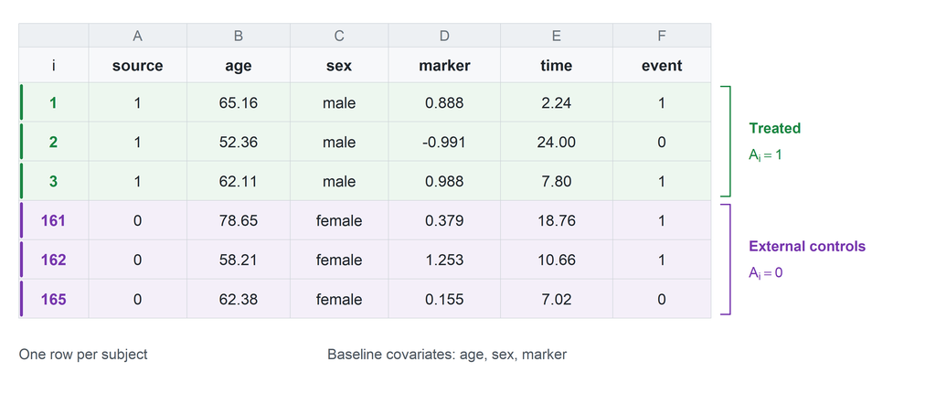

**Figure 2. Subject-level structure of the simulated example.** Each row represents one subject from the package dataset `example_external_controls`; $i$ is the row index in the original dataset. The three green rows are treated-cohort subjects (`source` $=A_i=1$), and the three purple rows are external controls (`source` $=A_i=0$); the colored brackets identify the two cohorts. The baseline covariate vector $X_i$ contains `age`, `sex`, and `marker`. The `time` column records $Y_i=\min(T_i,C_i)$, where $T_i$ and $C_i$ are event and censoring times. The `event` column records $\delta_i=I(T_i\le C_i)$: 1 denotes an observed event and 0 denotes right censoring. Two event rows and one censored row from each cohort are selected for illustration; this display is not the complete dataset. Numeric values are rounded for display. The letters A–F above the column names are spreadsheet-style column labels, distinct from the source indicator $A_i$.

```r
library(mecCox)
library(survival)
data(example_external_controls)
dat <- example_external_controls

A <- dat$source
I0 <- which(A == 0L)
I1 <- which(A == 1L)
n <- nrow(dat)
n0 <- length(I0)
n1 <- length(I1)
dat$A <- A
X_names <- c("age", "sex", "marker")

K <- 5L
seed <- 2026L
t_landmark <- c(3, 6, 9, 12, 15)
L <- length(t_landmark)
p <- L + 1L

data.frame(treated = n1, external_controls = n0,
           folds = K, landmarks = L, calibration_features = p)
```

```
#>   treated external_controls folds landmarks calibration_features
#> 1     160               320     5         5                    6
```

Run the code chunks in order. The five landmark times are fixed for this example; the same times and folds will be used in the package comparison.

## 2. MEC-Cox implementation steps

### 2-1. **[Step 1]** Construction of the cross-fitted predictor basis

Partition the pooled sample into $K$ folds, stratified by $A_i$, and let $\kappa(i)\in\{1,\ldots,K\}$ identify the fold containing subject $i$. Thus $i\in\mathcal J^{(\kappa(i))}$, and the training set for fold $k$ is $\mathcal J^{(-k)}=\{1,\ldots,n\}\setminus\mathcal J^{(k)}$. For each fold $k$, train the control-survival learner using only the external controls in $\mathcal I_0\cap\mathcal J^{(-k)}$, then evaluate it for **all** subjects in the held-out fold $\mathcal J^{(k)}$. Define the cross-fitted calibration-feature vector

$$\widehat h_i=
\left(1,\widehat S_0^{(-\kappa(i))}(t_1\mid X_i),\ldots,
\widehat S_0^{(-\kappa(i))}(t_{p-1}\mid X_i)\right)\in\mathbb R^p.$$

Here $L=p-1$ is the number of landmark times. Every non-intercept component is an out-of-sample prediction for subject $i$.

Figure 3 shows how each fold is held out in turn to construct these predictions. The same partition also supplies the held-out source-propensity estimates used in Step 2.

[figure not shown]

**Figure 3. Construction of out-of-fold nuisance predictions by $K$-fold cross-fitting (Supplement Figure S1).** The pooled sample of $n$ subjects is partitioned into folds $\mathcal J^{(1)},\ldots,\mathcal J^{(K)}$, stratified by source indicator $A_i$ ($1$ for treated subjects and $0$ for external controls). In row $k$, the blue block is the held-out validation fold $\mathcal J^{(k)}$; the gray blocks form its training complement $\mathcal J^{(-k)}=\{1,\ldots,n\}\setminus\mathcal J^{(k)}$. The arrows indicate fitting nuisance learners on the training subjects and then evaluating predictions for the held-out subjects. The source-propensity learner uses both cohorts in $\mathcal J^{(-k)}$, whereas the control-survival learner uses only external controls in $\mathcal I_0\cap\mathcal J^{(-k)}$, where $\mathcal I_0=\{i:A_i=0\}$.

Both learners predict for every subject in $\mathcal J^{(k)}$. If $\kappa(i)$ is subject $i$’s fold, these predictions give $\widehat\pi_i=\widehat\pi^{(-\kappa(i))}(X_i)$ and $\widehat h_i=(1,\widehat S_0^{(-\kappa(i))}(t_1\mid X_i),\ldots,\widehat S_0^{(-\kappa(i))}(t_L\mid X_i))$, where $X_i$ is the baseline covariate vector, $\widehat S_0$ predicts control survival, and $t_1,\ldots,t_L$ are the landmark times. Repeating the procedure over all $K$ folds supplies one held-out feature vector and propensity prediction per subject. The same folds are used for both learners. The schematic is drawn from the supplement’s editable TikZ code; the worked example uses $K=5$.

The same fold assignment is used for both learners throughout the calculation.

```r
set.seed(seed)
kappa <- integer(n)
for (a in c(0L, 1L)) {
  rows <- which(A == a)
  kappa[rows] <- sample(rep(seq_len(K), length.out = length(rows)))
}
```

We consider two implementations of the control-survival learner.

- **Cox proportional hazards regression** ([Cox, 1972](https://doi.org/10.1111/j.2517-6161.1972.tb00899.x); [Cox, 1975](https://doi.org/10.1093/biomet/62.2.269)). Fit the working model among the external-control subjects in the training fold,

  $$\lambda_0^{(-k)}(t\mid X)
  =\lambda_{00}^{(-k)}(t)\exp\{X^\top\beta_0^{(-k)}\},
  \qquad i\in\mathcal I_0\cap\mathcal J^{(-k)}.$$

  Let $\widehat\beta_0^{(-k)}$ and $\widehat\Lambda_{00}^{(-k)}(t)$ denote its fitted regression coefficient and baseline cumulative hazard estimator. For a validation subject,

  $$\widehat S_{0,\mathrm{Cox}}^{(-k)}(t_\ell\mid X_i)
  =\exp\left[-\widehat\Lambda_{00}^{(-k)}(t_\ell)
  \exp\{X_i^\top\widehat\beta_0^{(-k)}\}\right],
  \qquad \ell=1,\ldots,L.$$

  ```r
  predict_survival_cox <- function(training0, validation, fold_seed, settings) {
    survival_formula <- reformulate(X_names, response = "Surv(time, event)")
    outcome_fit <- coxph(
      survival_formula, data = training0,
      ties = "breslow", x = TRUE, singular.ok = FALSE,
      control = coxph.control(timefix = FALSE)
    )
    baseline <- basehaz(outcome_fit, centered = FALSE)
    j <- findInterval(t_landmark, baseline$time)
    Lambda00_hat <- numeric(L)
    Lambda00_hat[j > 0L] <- baseline$hazard[j[j > 0L]]
    lp <- predict(outcome_fit, newdata = validation,
                  type = "lp", reference = "zero")
    exp(-outer(exp(lp), Lambda00_hat))
  }
  ```

  The uncentered linear predictors are paired with the uncentered baseline cumulative hazard. At each landmark, the code uses the most recent cumulative hazard value; before the first event the hazard is zero and survival is one.
- **Random survival forest (RSF)** ([Ishwaran et al., 2008](https://doi.org/10.1214/08-AOAS169)). Alternatively, fit an RSF on the same external-control training subjects. For each tree $b=1,\ldots,B$, let $\widehat\Lambda_{0b}^{(-k)}(t\mid X_i)$ denote the terminal-node cumulative hazard estimate for a validation subject. The `ranger` implementation averages these cumulative hazards and then converts the result to survival:

  $$\widehat S_{0,\mathrm{RSF}}^{(-k)}(t_\ell\mid X_i)
  =\exp\left\{-\frac{1}{B}\sum_{b=1}^{B}
  \widehat\Lambda_{0b}^{(-k)}(t_\ell\mid X_i)\right\},
  \qquad \ell=1,\ldots,L.$$

  This gives a flexible, nonparametric estimate of the conditional control survival function at the same landmark times. The function below uses the forest survival output directly and evaluates its step function at those times.

  ```r
  predict_survival_rsf <- function(training0, validation, fold_seed, settings) {
    if (!requireNamespace("ranger", quietly = TRUE)) {
      stop("Install ranger to select survival_method = 'rsf'.")
    }
    training_frame <- training0[, c("time", "event", X_names), drop = FALSE]
    forest <- ranger::ranger(
      Surv(time, event) ~ ., data = training_frame,
      num.trees = settings$num_trees,
      min.node.size = settings$min_node_size,
      mtry = max(1L, floor(sqrt(length(X_names)))),
      splitrule = "logrank", num.random.splits = 1L,
      replace = TRUE, sample.fraction = 1,
      write.forest = TRUE, oob.error = FALSE,
      seed = fold_seed, num.threads = 1L
    )
    prediction <- predict(forest,
      data = validation[, X_names, drop = FALSE], num.threads = 1L
    )
    j <- findInterval(t_landmark, prediction$unique.death.times)
    S <- matrix(1, nrow = nrow(validation), ncol = L)
    observed <- which(j > 0L)
    if (length(observed)) {
      S[, observed] <- prediction$survival[, j[observed], drop = FALSE]
    }
    S
  }
  ```

Choose the survival learner below. The default is Cox; the fixed RSF settings provide an executable alternative for this worked example, with no tuning.

```r
survival_method <- "cox"             # "cox" or "rsf"
rsf_settings <- list(num_trees = 100L, min_node_size = 15L)
```

```r
predict_survival <- switch(survival_method,
  cox = predict_survival_cox, rsf = predict_survival_rsf,
  stop("Choose survival_method from cox and rsf.")
)
S0_hat <- matrix(NA_real_, nrow = n, ncol = L)
for (k in seq_len(K)) {
  train0 <- which(kappa != k & A == 0L)
  valid <- which(kappa == k)
  S0_hat[valid, ] <- predict_survival(
    dat[train0, ], dat[valid, ], as.integer(seed + k), rsf_settings
  )
}
colnames(S0_hat) <- paste0("S0(t=", t_landmark, ")")
H <- cbind(intercept = 1, S0_hat)
stopifnot(all(is.finite(H)), all(S0_hat >= 0 & S0_hat <= 1))
```

In both cases, the predictor basis summarizes the estimated counterfactual control-survival profile for each subject and is used only as a calibration feature. The final Cox model in Step 6 uses $A_i$ as its sole regression covariate.

### 2-2. **[Step 2]** Baseline ATT odds weights

We next construct the baseline weights around which the MEC calibration is performed. Using the same folds as in Step 1, estimate the source propensity score

$$\pi(X_i)=\Pr(A_i=1\mid X_i)$$

on the **pooled training sample** $\mathcal J^{(-k)}$. Write the fitted learner as $\widehat\pi^{(-k)}(X)$. For a subject in the held-out fold $i\in\mathcal J^{(k)}$, the cross-fitted prediction is

$$\widehat\pi_i=\widehat\pi^{(-k)}(X_i),$$

possibly truncated away from zero and one. Thus, each subject’s prediction is obtained without using that subject to train the propensity learner.

For external-control subjects $i\in\mathcal I_0$, form the estimated ATT odds and normalize them to have total mass equal to the treated cohort size:

$$\widehat q_i=\frac{\widehat\pi_i}{1-\widehat\pi_i},
\qquad
\widehat d_i=\frac{n_1\widehat q_i}
{\sum_{j\in\mathcal I_0}\widehat q_j},
\qquad
\sum_{i\in\mathcal I_0}\widehat d_i=n_1.$$

These normalized odds weights are the baseline for the Bregman calibration in Step 3. We consider two implementations of the source propensity-score learner.

- **Logistic regression.** The GLM working model is

  $$\pi_\gamma(X_i)
  =\frac{\exp(\gamma^\top\widetilde X_i)}
  {1+\exp(\gamma^\top\widetilde X_i)},$$

  where $\widetilde X_i$ contains an intercept and the selected baseline covariates. Fitting it on $\mathcal J^{(-k)}$ gives $\widehat\gamma^{(-k)}$, and the held-out prediction is

  $$\widehat\pi^{(-k)}_{\mathrm{glm}}(X_i)
  =\frac{\exp\{(\widehat\gamma^{(-k)})^\top\widetilde X_i\}}
  {1+\exp\{(\widehat\gamma^{(-k)})^\top\widetilde X_i\}}.$$

  ```r
  predict_ps_glm <- function(training, validation, fold_seed, settings) {
    fit <- glm(reformulate(X_names, response = "A"),
               data = training, family = binomial())
    stopifnot(isTRUE(fit$converged), all(is.finite(coef(fit))))
    as.numeric(predict(fit, newdata = validation, type = "response"))
  }
  ```

- **Flexible machine-learning classifier.** Alternatively, train a binary classifier on the same pooled training sample. Examples include deep learning (DL) ([LeCun et al., 2015](https://doi.org/10.1038/nature14539)), random forest ([Breiman, 2001](https://doi.org/10.1023/A:1010933404324)), and Bayesian additive regression trees (BART; [Chipman et al., 2010](https://doi.org/10.1214/09-AOAS285)). Each produces the held-out estimate

  $$\widehat\pi^{(-k)}_{\mathrm{ML}}(X_i)
  =\widehat{\Pr}(A_i=1\mid X_i).$$

  The functions below implement these alternatives directly. `"glm"` remains the default; changing `ps_method` selects one learner. The fixed settings are for this worked example, with no tuning. The optional packages are needed only when their corresponding learner is selected. The DL option also needs the torch runtime installed.

  ```r
  ps_method <- "glm"                 # "glm", "rf", "bart", or "mlp"
  ps_trim <- c(0.01, 0.99)
  ps_settings <- list(
    rf_trees = 100L, rf_min_node_size = 5L,
    bart_trees = 50L, bart_draws = 500L, bart_burn_in = 200L,
    bart_shrinkage = 2,
    mlp_hidden_units = c(16L, 8L), mlp_epochs = 50L
  )
  ```

  BART and DL use numeric predictor matrices. Factor coding is determined from the training fold and applied unchanged to the validation fold. Validation subjects do not determine factor levels or scaling values.

  ```r
  ps_predictor_matrices <- function(training, validation) {
    training <- training[, X_names, drop = FALSE]
    validation <- validation[, X_names, drop = FALSE]
    for (name in X_names) {
      if (is.factor(training[[name]]) || is.character(training[[name]])) {
        train_factor <- droplevels(factor(training[[name]]))
        observed_levels <- levels(train_factor)
        if (length(observed_levels) < 2L ||
            any(!as.character(validation[[name]]) %in% observed_levels)) {
          stop("A validation factor level is absent from its training fold.")
        }
        training[[name]] <- train_factor
        validation[[name]] <- factor(as.character(validation[[name]]),
                                     levels = observed_levels)
      }
    }
    formula <- reformulate(X_names)
    x_train <- model.matrix(formula, training)[, -1L, drop = FALSE]
    x_valid <- model.matrix(formula, validation)[, -1L, drop = FALSE]
    stopifnot(identical(colnames(x_train), colnames(x_valid)))
    list(training = x_train, validation = x_valid)
  }
  ```

  - **Random forest** (`ps_method = "rf"`).

    The random-forest classifier returns the probability of source group 1.

    ```r
    predict_ps_rf <- function(training, validation, fold_seed, settings) {
      if (!requireNamespace("ranger", quietly = TRUE)) {
        stop("Install ranger to select ps_method = 'rf'.")
      }
      training$A_factor <- factor(training$A, levels = c(0, 1))
      fit <- ranger::ranger(
        reformulate(X_names, response = "A_factor"), data = training,
        probability = TRUE, num.trees = settings$rf_trees,
        min.node.size = settings$rf_min_node_size,
        mtry = max(1L, floor(sqrt(length(X_names)))),
        seed = fold_seed, num.threads = 1L, oob.error = FALSE
      )
      as.numeric(predict(fit, data = validation[, X_names, drop = FALSE],
                         num.threads = 1L)$predictions[, "1"])
    }
    ```

  - **Bayesian additive regression trees (BART)** (`ps_method = "bart"`).

    For binary BART with a probit link, probabilities are averaged over posterior draws. The offset is supplied once when fitting; the returned latent draws already include it.

    ```r
    predict_ps_bart <- function(training, validation, fold_seed, settings) {
      if (!requireNamespace("dbarts", quietly = TRUE)) {
        stop("Install dbarts to select ps_method = 'bart'.")
      }
      x <- ps_predictor_matrices(training, validation)
      source_fraction <- min(max(mean(training$A), 0.01), 0.99)
      fit <- dbarts::bart(
        x.train = x$training, y.train = training$A, x.test = x$validation,
        ntree = settings$bart_trees, ndpost = settings$bart_draws,
        nskip = settings$bart_burn_in, k = settings$bart_shrinkage,
        binaryOffset = qnorm(source_fraction),
        seed = fold_seed, nthread = 1L, verbose = FALSE,
        keeptrees = FALSE, keeptrainfits = FALSE
      )
      if (!is.null(fit$prob.test.mean)) {
        return(as.numeric(fit$prob.test.mean))
      }
      if (!is.null(fit$prob.test)) {
        return(as.numeric(colMeans(fit$prob.test)))
      }
      latent_draws <- fit[["yhat.test"]]
      if (is.null(latent_draws)) {
        stop("The BART fit did not return posterior validation predictions.")
      }
      as.numeric(colMeans(pnorm(latent_draws)))
    }
    ```

  - **Deep learning (DL)** (`ps_method = "mlp"`).

    The worked example uses a feedforward multilayer perceptron (MLP). For the DL model, predictor means and standard deviations are computed on the training fold. The same transformation is applied to held-out subjects. The two hidden layers use ReLU activations; the output is the estimated probability of source group 1. Its internal validation subset is drawn only from the outer training fold.

    ```r
    predict_ps_mlp <- function(training, validation, fold_seed, settings) {
      if (!requireNamespace("brulee", quietly = TRUE) ||
          !requireNamespace("torch", quietly = TRUE)) {
        stop("Install brulee and torch to select ps_method = 'mlp'.")
      }
      x <- ps_predictor_matrices(training, validation)
      center <- colMeans(x$training)
      spread <- apply(x$training, 2L, sd)
      spread[!is.finite(spread) | spread < 1e-12] <- 1
      train_frame <- as.data.frame(scale(x$training, center, spread))
      valid_frame <- as.data.frame(scale(x$validation, center, spread))
      names(train_frame) <- names(valid_frame) <-
        make.names(names(train_frame), unique = TRUE)
      train_frame$A <- factor(training$A, levels = c(0, 1))

      old_threads <- torch::torch_get_num_threads()
      old_state <- torch::torch_get_rng_state()
      on.exit({
        torch::torch_set_rng_state(old_state)
        torch::torch_set_num_threads(old_threads)
      }, add = TRUE)
      torch::torch_set_num_threads(1L)
      torch::torch_manual_seed(fold_seed)
      fit <- brulee::brulee_mlp(
        A ~ ., data = train_frame,
        hidden_units = settings$mlp_hidden_units,
        epochs = settings$mlp_epochs, activation = "relu",
        optimizer = "ADAMw", learn_rate = 0.01,
        penalty = 0.001, dropout = 0.1,
        batch_size = min(128L, nrow(train_frame)),
        validation = 0.1, stop_iter = 10L,
        device = "cpu", verbose = FALSE
      )
      as.numeric(predict(fit, new_data = valid_frame, type = "prob")[[".pred_1"]])
    }
    ```

The common fold loop below applies the selected learner to $\mathcal J^{(-k)}$ and evaluates it on $\mathcal J^{(k)}$. The fold-specific seed controls stochastic learners; it does not change the shared fold assignment `kappa` constructed in Step 1.

```r
with_ps_seed <- function(value, expression) {
  had_seed <- exists(".Random.seed", envir = .GlobalEnv, inherits = FALSE)
  if (had_seed) old_seed <- get(".Random.seed", envir = .GlobalEnv)
  on.exit({
    if (had_seed) assign(".Random.seed", old_seed, envir = .GlobalEnv)
    else if (exists(".Random.seed", envir = .GlobalEnv, inherits = FALSE)) {
      rm(".Random.seed", envir = .GlobalEnv)
    }
  }, add = TRUE)
  set.seed(value)
  force(expression)
}
```

```r
predict_ps <- switch(ps_method,
  glm = predict_ps_glm, rf = predict_ps_rf,
  bart = predict_ps_bart, mlp = predict_ps_mlp,
  stop("Choose ps_method from glm, rf, bart, and mlp.")
)
pi_hat <- numeric(n)
for (k in seq_len(K)) {
  train <- which(kappa != k)
  valid <- which(kappa == k)
  fold_seed <- as.integer(seed + k)
  held_out <- with_ps_seed(fold_seed,
    predict_ps(dat[train, ], dat[valid, ], fold_seed, ps_settings)
  )
  stopifnot(length(held_out) == length(valid), all(is.finite(held_out)),
            all(held_out >= 0 & held_out <= 1))
  pi_hat[valid] <- held_out
}
pi_hat <- pmin(pmax(pi_hat, ps_trim[1]), ps_trim[2])
```

Using the held-out predictions, compute the normalized baseline weights defined above.

```r
q_hat <- pi_hat[I0] / (1 - pi_hat[I0])
d_hat <- n1 * q_hat / sum(q_hat)
stopifnot(all(is.finite(d_hat)), all(d_hat > 0))
c(baseline_weight_total = sum(d_hat), treated_count = n1)
```

```
#> baseline_weight_total         treated_count
#>                   160                   160
```

`d_hat` contains external-control weights only, in the order of `I0`; changing the propensity learner leaves this construction unchanged.

### 2-3. **[Step 3]** Formulation of the primal problem

Write the index sets as

$$\mathcal I_0=\{i_1^0,\ldots,i_{n_0}^0\},
\qquad
\mathcal I_1=\{i_1^1,\ldots,i_{n_1}^1\},$$

where $i_m^0$ denotes the index of the $m$th external-control subject and $i_m^1$ denotes the index of the $m$th treated subject.

Stacking the vectors $\widehat h_i$ obtained in Step 1 as rows within each cohort, define the calibration-feature matrices

$$H_0
=
\begin{pmatrix}
\widehat h_{i_1^0}\\
\vdots\\
\widehat h_{i_{n_0}^0}
\end{pmatrix}
=
\begin{pmatrix}
1 & \widehat S_0^{(-\kappa(i_1^0))}(t_1\mid X_{i_1^0}) & \cdots & \widehat S_0^{(-\kappa(i_1^0))}(t_{p-1}\mid X_{i_1^0})\\
\vdots & \vdots & \ddots & \vdots\\
1 & \widehat S_0^{(-\kappa(i_{n_0}^0))}(t_1\mid X_{i_{n_0}^0}) & \cdots & \widehat S_0^{(-\kappa(i_{n_0}^0))}(t_{p-1}\mid X_{i_{n_0}^0})
\end{pmatrix}
\in\mathbb R^{n_0\times p},$$

and

$$H_1
=
\begin{pmatrix}
\widehat h_{i_1^1}\\
\vdots\\
\widehat h_{i_{n_1}^1}
\end{pmatrix}
=
\begin{pmatrix}
1 & \widehat S_0^{(-\kappa(i_1^1))}(t_1\mid X_{i_1^1}) & \cdots & \widehat S_0^{(-\kappa(i_1^1))}(t_{p-1}\mid X_{i_1^1})\\
\vdots & \vdots & \ddots & \vdots\\
1 & \widehat S_0^{(-\kappa(i_{n_1}^1))}(t_1\mid X_{i_{n_1}^1}) & \cdots & \widehat S_0^{(-\kappa(i_{n_1}^1))}(t_{p-1}\mid X_{i_{n_1}^1})
\end{pmatrix}
\in\mathbb R^{n_1\times p}.$$

Here $H_0$ contains the cross-fitted control-survival features for external-control subjects, whereas $H_1$ contains the same features evaluated at the covariate values of treated subjects.

The target calibration total is then expressed as the $p$-dimensional vector

$$T_H
=
H_1^\top \mathbf 1_{n_1}
=
\sum_{i\in\mathcal I_1}\widehat h_i
\in \mathbb{R}^{p}.$$

For $i\in\mathcal I_0$, let $\widehat d_i$ denote the normalized baseline ATT odds weight,

$$\widehat d_i
=
\frac{n_1\widehat q_i}
{\sum_{j\in\mathcal I_0}\widehat q_j},
\qquad
\widehat q_i
=
\frac{\widehat\pi_i}{1-\widehat\pi_i}
=
\frac{\widehat\pi^{(-k)}(X_i)}{1-\widehat\pi^{(-k)}(X_i)},$$

where $k=\kappa(i)$ and $\widehat\pi_i$ is obtained in Step 2.

The MEC-Cox calibrated weights are obtained by the Bregman projection

$$\widehat w
=
\arg\min_{\{w_i>0:i\in\mathcal I_0\}}
\sum_{i\in\mathcal I_0}
D_G(w_i\|\widehat d_i)$$

subject to

$$H_0^\top w
=
H_1^\top\mathbf 1_{n_1}
=
T_H\in \mathbb{R}^{p},$$

where

$$D_G(w_i\|\widehat d_i)
=
G(w_i)-G(\widehat d_i)-g(\widehat d_i)(w_i-\widehat d_i),
\qquad
g=G',$$

and $G$ is a strictly convex generator.

Directly solving this primal problem would require optimizing over $n_0$ external-control weights. Instead, MEC-Cox solves the equivalent low-dimensional dual problem, whose dimension is only $p$, the number of calibration features.

The intercept constraint preserves the total external-control weight $n_1$; the other constraints match the treated cohort’s predicted-survival totals. The following code constructs these matrices and uses the KL generator $G(u)=u\log u$ for the worked example.

```r
H0 <- H[I0, , drop = FALSE]
H1 <- H[I1, , drop = FALSE]
T_H <- colSums(H1)

# KL generator from the manuscript: G(u) = u log(u), for u > 0.
G <- function(u) u * log(u)
g <- function(u) 1 + log(u)
g_inv <- function(v) exp(v - 1)
g_prime <- function(u) 1 / u

data.frame(feature = colnames(H),
           treated_total = T_H,
           baseline_control_total = as.numeric(crossprod(H0, d_hat)),
           row.names = NULL)
```

```
#>     feature treated_total baseline_control_total
#> 1 intercept      160.0000               160.0000
#> 2   S0(t=3)      140.4550               140.9055
#> 3   S0(t=6)      122.9990               123.6722
#> 4   S0(t=9)      104.3938               105.3782
#> 5  S0(t=12)       94.0362                95.0081
#> 6  S0(t=15)       83.2960                84.4723
```

### 2-4. **[Step 4]** Conversion to the dual problem

We next convert the constrained primal problem into a low-dimensional dual problem. Recall that the MEC-Cox calibration problem is

$$\widehat w
=
\arg\min_{\{w_i>0:i\in\mathcal I_0\}}
\sum_{i\in\mathcal I_0}
D_G(w_i\|\widehat d_i)
\quad
\text{subject to}
\quad
H_0^\top w=T_H \in \mathbb{R}^{p}.$$

Let $\lambda\in\mathbb R^p$ denote the Lagrange multiplier associated with the calibration constraint. Define the Lagrangian

$$\mathcal L(w,\lambda)
=
\sum_{i\in\mathcal I_0}
D_G(w_i\|\widehat d_i)
-
\lambda^\top
\left(
H_0^\top w
-
T_H
\right).$$

Because

$$D_G(w_i\|\widehat d_i)
=
G(w_i)-G(\widehat d_i)-g(\widehat d_i)(w_i-\widehat d_i),
\qquad g=G',$$

we have

$$\frac{\partial}{\partial w_i}
D_G(w_i\|\widehat d_i)
=
g(w_i)-g(\widehat d_i).$$

Therefore, the stationarity condition of the Karush–Kuhn–Tucker (KKT) equations is

$$\frac{\partial \mathcal L(w,\lambda)}{\partial w_i}
=
g(w_i)-g(\widehat d_i)-\lambda^\top\widehat h_i
=
0,
\qquad i\in\mathcal I_0.$$

Equivalently,

$$g(w_i)
=
g(\widehat d_i)+\lambda^\top\widehat h_i.$$

Since $G$ is strictly convex, $g=G'$ is strictly increasing and hence invertible on its domain. Thus, for any fixed admissible $\lambda$, the primal weight satisfying the stationarity condition is

$$w_i(\lambda)
=
g^{-1}\{g(\widehat d_i)+\lambda^\top\widehat h_i\},
\qquad i\in\mathcal I_0.$$

The remaining KKT condition is primal feasibility

$$H_0^\top w(\lambda)=T_H.$$

Substituting the dual representation $w_i(\lambda)$ into the calibration constraint yields the dual estimating equation

$$F(\lambda)
=
\sum_{i\in\mathcal I_0}
w_i(\lambda)\widehat h_i
-
T_H
=
0.$$

Equivalently,

$$F(\lambda)
=
\sum_{i\in\mathcal I_0}
\widehat h_i
g^{-1}\{g(\widehat d_i)+\lambda^\top\widehat h_i\}
-
\sum_{i\in\mathcal I_1}\widehat h_i
=
0,$$

or, in matrix form,

$$F(\lambda)
=
H_0^\top w(\lambda)-T_H.$$

Thus, instead of optimizing over the $n_0$-dimensional vector $w$, MEC-Cox solves the $p$-dimensional nonlinear equation $F(\lambda)=0$.

The dual estimating equation also supplies the calibration component of the stacked system for variance estimation.

For the KL choice used in the code, $g(u)=1+\log u$ and $g^{-1}(v)=\exp(v-1)$. Consequently,

$$w_i(\lambda)=\widehat d_i\exp(\lambda^\top\widehat h_i).$$

The functions below evaluate the implied weights and the dual residual. At $\lambda=0$, the implied weights are the baseline weights.

```r
w_of_lambda <- function(lambda) {
  nu <- g(d_hat) + as.numeric(H0 %*% lambda)
  g_inv(nu)
}

F <- function(lambda) {
  as.numeric(crossprod(H0, w_of_lambda(lambda)) - T_H)
}

lambda0 <- numeric(p)
stopifnot(max(abs(w_of_lambda(lambda0) - d_hat)) < 1e-12)
```

### 2-5. **[Step 5]** Dual Newton solver

The Newton update is based on the Jacobian of $F(\lambda)$. We view the dual calibration map as

$$F:\mathcal D_{\lambda}\subseteq \mathbb R^{p}\longrightarrow \mathbb R^{p},$$

where

$$\mathcal D_{\lambda}
=
\left\{
\lambda\in\mathbb R^{p}:
g(\widehat d_i)+\lambda^\top \widehat h_i
\in \operatorname{dom}(g^{-1})
\ \text{for all } i\in\mathcal I_0
\right\}.$$

That is, the domain of $F$ consists of all dual parameters $\lambda$ for which the implied weights $w_i(\lambda) = g^{-1}\{g(\widehat d_i)+\lambda^\top \widehat h_i\},$ $(i\in\mathcal I_0)$ are well-defined.

By the stationarity equation in Step 4, let

$$\nu_i(\lambda)
=
g(\widehat d_i)+\lambda^\top\widehat h_i,
\qquad
w_i(\lambda)=g^{-1}\{\nu_i(\lambda)\}.$$

Assuming $g'(w)>0$ at the weights considered, the inverse-function derivative is

$$\frac{\partial w_i(\lambda)}{\partial \nu_i}
=
\frac{1}{g'\{w_i(\lambda)\}},$$

and hence the Jacobian of $F(\lambda)$ is

$$J(\lambda)
=
\frac{\partial F(\lambda)}{\partial \lambda^\top}
=
\sum_{i\in\mathcal I_0}
\frac{1}{g'\{w_i(\lambda)\}}
\widehat h_i\widehat h_i^\top \in \mathbb{R}^{p \times p}.$$

In matrix form,

$$J(\lambda)
=
H_0^\top
\operatorname{diag}
\left[
\frac{1}{g'\{w_i(\lambda)\}}:i\in\mathcal I_0
\right]
H_0 \in \mathbb{R}^{p \times p}.$$

At iteration $m$, the Newton direction $\Delta_m$ solves

$$\{J(\lambda_m)+\rho I_{p}\}\Delta_m
=
F(\lambda_m),$$

where $\rho>0$ is a small ridge constant used for numerical stability. The dual parameter is updated by

$$\lambda_{m+1}
=
\lambda_m-\alpha_m\Delta_m=
\lambda_m-\alpha_m \{J(\lambda_m)+\rho I_{p}\}^{-1}F(\lambda_m),$$

where $\alpha_m\in(0,1]$ is chosen by step-halving if necessary to keep all dual arguments $\nu_i(\lambda_{m+1}) = g(\widehat d_i)+\lambda_{m+1}^\top\widehat h_i$ inside the domain of $g^{-1}$. The iteration stops when the calibration residual is sufficiently small, for example when

$$\|F(\lambda_m)\|_2
=
\left\|
H_0^\top w(\lambda_m)-T_H
\right\|_2
\le \varepsilon$$

for a prespecified tolerance $\varepsilon$.

The ridge constant $\rho$, the step-halving rule, and the stopping tolerance $\varepsilon$ are user-specified numerical choices. For the illustrative solver below, we use $\rho=10^{-8}$, initialize $\alpha_m=1$, and apply step-halving only when necessary to keep the dual argument within the domain of $g^{-1}$. The stopping tolerance is $\varepsilon=10^{-10}$, with at most 100 Newton iterations.

For the KL generator, $1/g'(w_i)=w_i$ and $\operatorname{dom}(g^{-1})=\mathbb R$. The step-halving guard in the code also rejects weights that overflow or underflow in finite-precision arithmetic. It starts each update with $\alpha_m=1$, then halves the step until the implied weights are finite and positive.

```r
J <- function(lambda) {
  w <- w_of_lambda(lambda)
  crossprod(H0, H0 * (1 / g_prime(w)))
}

rho <- 1e-8
epsilon <- 1e-10
max_iter <- 100L
lambda <- lambda0
converged <- FALSE
history <- data.frame(iteration = integer(), residual_L2 = numeric())

for (m in 0:max_iter) {
  residual <- F(lambda)
  residual_L2 <- sqrt(sum(residual^2))
  history <- rbind(history, data.frame(iteration = m,
                                      residual_L2 = residual_L2))
  if (is.finite(residual_L2) && residual_L2 <= epsilon) {
    converged <- TRUE
    break
  }
  if (m == max_iter) break

  Delta <- solve(J(lambda) + rho * diag(p), residual)
  alpha <- 1
  accepted <- FALSE
  for (halving in 0:60) {
    candidate <- lambda - alpha * Delta
    w_candidate <- w_of_lambda(candidate)
    if (all(is.finite(w_candidate)) && all(w_candidate > 0)) {
      accepted <- TRUE
      break
    }
    alpha <- alpha / 2
  }
  if (!accepted) stop("No admissible Newton step was found.")
  lambda <- candidate
}

if (!converged) stop("The dual solver did not reach the stated tolerance.")
lambda_hat <- lambda
w_hat <- w_of_lambda(lambda_hat)
history
```

```
#>   iteration residual_L2
#> 1         0 1.98840e+00
#> 2         1 3.02732e+00
#> 3         2 5.82436e-02
#> 4         3 3.65760e-05
#> 5         4 1.96874e-11
```

The balance table makes the constraint $H_0^\top\widehat w=T_H$ visible.

```r
knitr::kable(data.frame(
  feature = colnames(H),
  treated_mean = T_H / n1,
  baseline_control_mean = as.numeric(crossprod(H0, d_hat)) / n1,
  calibrated_control_mean = as.numeric(crossprod(H0, w_hat)) / n1
), digits = 6, row.names = FALSE,
col.names = c("Feature", "Treated mean", "Baseline control mean",
              "Calibrated control mean"))
```

| Feature | Treated mean | Baseline control mean | Calibrated control mean |
| --- | --- | --- | --- |
| intercept | 1.000000 | 1.000000 | 1.000000 |
| S0(t=3) | 0.877844 | 0.880659 | 0.877844 |
| S0(t=6) | 0.768744 | 0.772951 | 0.768744 |
| S0(t=9) | 0.652461 | 0.658614 | 0.652461 |
| S0(t=12) | 0.587726 | 0.593801 | 0.587726 |
| S0(t=15) | 0.520600 | 0.527952 | 0.520600 |

The dual formulation solves for $p$ calibration parameters instead of $n_0$ external-control weights. Its parameter dimension is $p$, although forming the Jacobian still requires contributions from all $n_0$ external-control subjects. At each iteration, assembling the $p\times p$ Jacobian $J(\lambda)$ requires $O(n_0p^2)$ operations, and solving for the Newton step requires $O(p^3)$ operations.

### 2-6. **[Step 6]** Final MEC-Cox estimator

After convergence of the dual Newton solver, let $\widehat\lambda$ denote the resulting dual solution and define the calibrated external-control weights by

$$\widehat w_i
=
g^{-1}\{g(\widehat d_i)+\widehat\lambda^\top \widehat h_i\},
\qquad i\in \mathcal I_0 .$$

The final MEC-Cox estimating-equation weight is

$$\widetilde\omega_i
=
\begin{cases}
1, & i\in\mathcal I_1 \quad \text{(treated cohort)},\\
\widehat w_i, & i\in\mathcal I_0 \quad \text{(external-control cohort)}.
\end{cases}$$

Here, we write $\widetilde\omega_i$ for $\widetilde\omega_i(\widehat\lambda)$, suppressing dependence on the fitted dual parameter for notational simplicity. The tilde distinguishes it from the logistic IPW weight $\widehat\omega_i(\widehat\gamma)$.

Here $\mathcal Y_i(t)$ is the at-risk indicator and $\mathcal N_i(t)$ is the event counting process. Using the final weights, define

$$S_{\mathrm{MEC},\widetilde\omega}^{(r)}(t;\theta)
=
\sum_{i=1}^n
\widetilde\omega_i
\mathcal{Y}_i(t)\exp(\theta A_i)A_i^r,
\qquad r=0,1,$$

and

$$\overline A_{\mathrm{MEC},\widetilde\omega}(t;\theta)
=
\frac{S_{\mathrm{MEC},\widetilde\omega}^{(1)}(t;\theta)}
{S_{\mathrm{MEC},\widetilde\omega}^{(0)}(t;\theta)} .$$

The MEC-Cox estimator is the solution to the weighted Cox estimating equation

$$U_n^{\mathrm{MEC}}(\theta)
=U_n^{\widetilde\omega}(\theta)
=
\sum_{i=1}^n
\int
\widetilde\omega_i
\{A_i-\overline A_{\mathrm{MEC},\widetilde\omega}(t;\theta)\}
\,d\mathcal{N}_i(t)
=
0.$$

Equivalently, $\widehat\theta_{\mathrm{MEC}}$ maximizes the weighted Cox partial log-likelihood

$$\ell_{\mathrm{MEC}}(\theta)
=
\sum_{i=1}^n
\widetilde\omega_i
\int
\left[
\theta A_i
-
\log\{S_{\mathrm{MEC},\widetilde\omega}^{(0)}(t;\theta)\}
\right]
\,d\mathcal{N}_i(t).$$

The final MEC-Cox hazard-ratio estimator is therefore

$$\widehat{\mathrm{HR}}_{\mathrm{MEC}}
=
\exp(\widehat\theta_{\mathrm{MEC}}).$$

In R, the point estimate is obtained by fitting a weighted Cox model with `A` as its sole covariate. Breslow handling of tied events matches the package.

```r
omega_tilde <- rep(1, n)
omega_tilde[I0] <- w_hat
dat$omega_tilde <- omega_tilde

final_fit <- coxph(
  Surv(time, event) ~ A, data = dat, weights = omega_tilde,
  ties = "breslow", robust = FALSE,
  control = coxph.control(timefix = FALSE)
)
theta_hat <- unname(coef(final_fit)["A"])
HR_hat <- exp(theta_hat)
data.frame(log_hazard_ratio = theta_hat, hazard_ratio = HR_hat)
```

```
#>   log_hazard_ratio hazard_ratio
#> 1        0.0899067      1.09407
```

This step illustrates the point estimator. For the MEC stacked-sandwich standard error and confidence interval, use `fit_mec_cox()` as below; the ordinary weighted `coxph()` standard error is not that variance estimator.

## 3. Algorithm summary

**Algorithm S1. Computational algorithm for the MEC-Cox estimator**

1. Partition the pooled sample into $K$ folds, stratified by the source indicator $A_i$.
2. For each validation subject $i\in\mathcal J^{(k)}$, compute cross-fitted nuisance estimates

   $$\widehat\pi_i=\widehat\pi^{(-k)}(X_i),
   \qquad
   \widehat h_i=
   \left(1,\widehat S_0^{(-k)}(t_1\mid X_i),\ldots,
   \widehat S_0^{(-k)}(t_{p-1}\mid X_i)\right),$$

   where $\widehat\pi^{(-k)}$ is trained on $\mathcal J^{(-k)}$, and $\widehat S_0^{(-k)}$ is trained using external controls in $\mathcal I_0\cap\mathcal J^{(-k)}$.
3. For $i\in\mathcal I_0$, define the normalized baseline ATT odds weight

   $$\widehat d_i=
   \frac{n_1\widehat q_i}{\sum_{j\in\mathcal I_0}\widehat q_j},
   \qquad
   \widehat q_i=\frac{\widehat\pi_i}{1-\widehat\pi_i}.$$
4. Solve the dual calibration equation

   $$F(\lambda)=
   \sum_{i\in\mathcal I_0}
   \widehat h_i
   g^{-1}\{g(\widehat d_i)+\lambda^\top\widehat h_i\}
   -\sum_{i\in\mathcal I_1}\widehat h_i=0$$

   by a damped Newton solver, and denote the solution by $\widehat\lambda$.
5. Recover the MEC-updated external-control weights and the final estimating-equation weights:

   $$\widehat w_i=
   g^{-1}\{g(\widehat d_i)+\widehat\lambda^\top\widehat h_i\},
   \qquad i\in\mathcal I_0,$$

   $$\widetilde\omega_i=
   \widetilde\omega_i(\widehat\lambda)=
   \begin{cases}
   1, & i\in\mathcal I_1,\\
   \widehat w_i, & i\in\mathcal I_0.
   \end{cases}$$
6. Report $\widehat{\mathrm{HR}}_{\mathrm{MEC}}=\exp(\widehat\theta_{\mathrm{MEC}})$ by solving

   $$U_n^{\mathrm{MEC}}(\theta)=
   U_n^{\widetilde\omega}(\theta)=
   \sum_{i=1}^n\int\widetilde\omega_i
   \{A_i-\overline A_{\mathrm{MEC},\widetilde\omega}(t;\theta)\}
   \,d\mathcal N_i(t)=0.$$

Algorithm lines 1–3 construct the inputs developed in Steps 1–2 above; line 4 combines Steps 3–5; and lines 5–6 give the final calculation in Step 6.

## 4. More technical details

### 4-1. Agreement with `fit_mec_cox()`

The package call performs calibration and estimation using the same inputs. We pass the cross-fitted propensity scores from Step 2 through `ps_predictions`, so the selected classifier is not fitted again. The package reconstructs the same folds from `seed` and fits the selected Cox or RSF survival learner with the same landmark times and settings.

Choose `kl_derivative = "numerical"` (default) or `"analytic"` for the KL cross-derivative used in the sandwich variance. The detailed KL cross-derivative illustration below derives both choices and compares them using this fitted example.

```r
# Choose one KL cross-derivative calculation; numerical is the default.
kl_derivative <- "numerical"  # Change to "analytic" for the analytic calculation.

mec <- fit_mec_cox(
  example_external_controls,
  time = "time", event = "event", source = "source",
  covariates = X_names, ps_predictions = pi_hat,
  survival_learner = survival_method,
  kl_derivative = kl_derivative,
  n_folds = K, landmarks = t_landmark, seed = seed, ps_trim = ps_trim,
  nuisance_settings = "standard", rsf_auto_tune = FALSE,
  rsf_num_trees = rsf_settings$num_trees,
  rsf_min_node_size = rsf_settings$min_node_size
)

# First verify the ingredients, before comparing the calibrated estimates.
stopifnot(
  isTRUE(mec$ps_predictions_supplied),
  identical(kappa, mec$fold_id),
  max(abs(pi_hat - mec$ps_oof)) < 1e-12,
  max(abs(H - mec$basis)) < 1e-12,
  max(abs(d_hat - mec$baseline_weights[I0])) < 1e-12
)

knitr::kable(data.frame(
  calculation = c("Steps 1-6", "fit_mec_cox()"),
  log_hazard_ratio = c(theta_hat, mec$theta),
  hazard_ratio = c(HR_hat, mec$hr),
  control_weight_total = c(sum(w_hat), sum(mec$weights[I0])),
  max_mean_balance_residual = format(
    c(max(abs(F(lambda_hat))) / n1,
      mec$calibration$max_mean_balance_residual), scientific = TRUE, digits = 3
  )
), digits = 6,
col.names = c("Calculation", "Log HR", "HR", "Control weight total",
              "Max. mean residual"))
```

| Calculation | Log HR | HR | Control weight total | Max. mean residual |
| --- | --- | --- | --- | --- |
| Steps 1-6 | 0.089907 | 1.09407 | 160 | 8.42e-14 |
| fit_mec_cox() | 0.089907 | 1.09407 | 160 | 8.46e-14 |

```r
stopifnot(max(abs(w_hat - mec$weights[I0])) < 1e-5,
          abs(theta_hat - mec$theta) < 1e-7)
```

The worked solver uses S2.4’s numerical choices. The package solves the same KL balance equation using a scaled ridge, a dual-objective line search, and `calibration_tol` applied to $\max|F|/n_1$ (default $10^{-8}$). Accordingly, the comparison checks numerical agreement rather than identical iterations. The public `fit_mec_cox()` implementation uses KL calibration; the supplement’s general $G$ notation also describes other generators.

For routine analysis, the package also returns the MEC uncertainty estimates:

```r
data.frame(hazard_ratio = mec$hr, SE_log_hazard_ratio = mec$se,
           CI_lower = unname(mec$conf_int["lower"]),
           CI_upper = unname(mec$conf_int["upper"]))
```

```
#>   hazard_ratio SE_log_hazard_ratio CI_lower CI_upper
#> 1      1.09407            0.135446 0.838986  1.42672
```

### 4-2. Comparison with standard ATT-IPW Cox methods

We now compare MEC-Cox with the three standard ATT-IPW Cox analyses described in the paper: **naive**, **robust sandwich**, and **corrected sandwich**. These three analyses share one set of baseline ATT weights and one weighted Cox point estimate. Their standard errors and confidence intervals differ because they use different variance estimators. MEC-Cox uses its calibrated weights and the stacked sandwich variance from the preceding implementation.

For the standard comparators, `fit_att_ipw_cox()` fits a logistic-regression source propensity model once to the full pooled sample. It converts the fitted probabilities to external-control odds and normalizes these weights to sum to $n_1$, using the same odds-and-normalization construction as Step 2. Treated subjects retain weight one. The call below uses the same subjects and baseline covariates as the worked MEC-Cox example.

1. **Naive: ATT-IPW Cox with naive model-based variance.** This analysis uses the usual inverse-information variance from the weighted Cox partial likelihood, treating the estimated ATT weights as fixed. It adds neither a robust sandwich correction nor an estimating-equation block for the fitted propensity model. This corresponds to the model-based variance comparator discussed in the paper and by [Austin (2016)](https://doi.org/10.1002/sim.7084).
2. **Robust sandwich: ATT-IPW Cox with Lin–Wei/Binder robust variance.** This analysis uses the same ATT-IPW coefficient as the naive analysis, but constructs its variance from the subject-level Cox contributions, including their effects through the weighted risk sets. It treats the fitted propensity-score weights as fixed. Consequently, it does not incorporate their estimation through the logistic score equation, and it can yield conservative inference. See [Lin and Wei (1989)](https://doi.org/10.1080/01621459.1989.10478874), [Binder (1992)](https://doi.org/10.1093/biomet/79.1.139), and [Shu et al. (2021)](https://doi.org/10.1111/biom.13332).
3. **Corrected sandwich: ATT-IPW Cox with Shu corrected sandwich variance.** This analysis retains the same ATT-IPW coefficient and stacks the weighted Cox estimating equation with the logistic source-propensity score equation. The cross-derivative accounts for the dependence of the normalized ATT weights on the fitted logistic coefficients. The package follows the paper’s joint Cox/logistic-score convention, based on [Shu et al. (2021)](https://doi.org/10.1111/biom.13332). Its validity relies on the corresponding propensity-model and regularity conditions; this correction does not repair misspecified propensity weights or directly extend the logistic score calculation to an arbitrary ML learner.
4. **MEC-Cox: calibrated weights with the proposed stacked sandwich variance.** This analysis uses the cross-fitted source propensities and control-survival features from Steps 1–2, calibrates the external-control weights in Steps 3–5, and fits the final weighted Cox model in Step 6. Its variance stacks the Cox contribution with the calibration equations. The table reuses `mec` from Section 4-1, including the selected propensity learner, survival learner, and `kl_derivative` option.

The standard ATT-IPW comparators use the full-sample logistic fit, whereas MEC-Cox uses the selected cross-fitted propensity learner and subsequent calibration. The comparison therefore follows the paper’s complete methods: differences between the ATT-IPW and MEC-Cox point estimates reflect their weight construction, including propensity fitting and calibration. Changing `ps_method` in Step 2 changes the MEC-Cox row; the three standard comparator rows retain their logistic-regression specification.

```r
att_ipw <- fit_att_ipw_cox(
  dat, time = "time", event = "event", source = "source",
  covariates = X_names, ps_clip = ps_trim,
  conf_level = mec$conf_level
)

variance_methods <- c("naive", "robust", "corrected")
att_intervals <- att_ipw$conf_int[
  match(variance_methods, att_ipw$conf_int$method), , drop = FALSE
]
stopifnot(identical(att_intervals$method, variance_methods))

method_comparison <- data.frame(
  Method = c("ATT-IPW: naive model-based",
             "ATT-IPW: Lin-Wei/Binder robust",
             "ATT-IPW: Shu corrected", "MEC-Cox"),
  Log_HR = c(rep(att_ipw$theta, 3L), mec$theta),
  HR = c(rep(att_ipw$hr, 3L), mec$hr),
  SE = c(unname(att_ipw$se[variance_methods]), mec$se),
  Lower = c(att_intervals$hazard_lower, unname(mec$conf_int["lower"])),
  Upper = c(att_intervals$hazard_upper, unname(mec$conf_int["upper"])),
  check.names = FALSE
)
knitr::kable(method_comparison, digits = 4, row.names = FALSE,
             col.names = c("Method", "Log HR", "HR", "SE (log HR)",
                           "CI lower", "CI upper"),
             caption = sprintf("Comparison using %g%% confidence intervals.",
                               100 * mec$conf_level))
```

Comparison using 95% confidence intervals.

| Method | Log HR | HR | SE (log HR) | CI lower | CI upper |
| --- | --- | --- | --- | --- | --- |
| ATT-IPW: naive model-based | 0.0935 | 1.0980 | 0.1475 | 0.8224 | 1.4660 |
| ATT-IPW: Lin-Wei/Binder robust | 0.0935 | 1.0980 | 0.1493 | 0.8195 | 1.4711 |
| ATT-IPW: Shu corrected | 0.0935 | 1.0980 | 0.1416 | 0.8319 | 1.4493 |
| MEC-Cox | 0.0899 | 1.0941 | 0.1354 | 0.8390 | 1.4267 |

The first three rows have the same log hazard ratio and hazard ratio. Their different intervals arise entirely from their standard errors. All intervals are Wald intervals obtained on the log-hazard-ratio scale and then exponentiated. The MEC-Cox row can differ in both its point estimate and its standard error because it uses calibrated weights and a different stacked estimating system. A smaller reported standard error in this example is a comparison of estimated uncertainty for these data; bias and coverage require the repeated-sampling evaluations presented in the paper.

### 4-3. KL cross-derivative: numerical and analytic calculation

The `kl_derivative` option in `fit_mec_cox()` selects how one block of the stacked-sandwich Jacobian is evaluated. Its default is `"numerical"`; `"analytic"` uses the KL identity derived below. Both choices use the same estimated propensity scores, prognostic basis, calibrated weights, and Cox coefficient. The choice concerns the variance calculation after fitting. To select a method, change `kl_derivative` in the package call above and rerun from that chunk. The comparison below always evaluates both choices and identifies the selected one.

Write $U(\theta,\lambda)=U_{\mathrm{MEC},\theta}(\theta,\lambda)$ for the weighted Cox score from Step 6. The cross-derivative is the row vector

$$D_{\theta\lambda}(\theta,\lambda)
=\frac{\partial U(\theta,\lambda)}{\partial\lambda^\top}
\in\mathbb R^{1\times p}.$$

Here the nuisance predictions, $\widehat d_i$, $\widehat h_i$, and $\theta$ are held fixed while $\lambda$ varies. This differs from the calibration Jacobian $J(\lambda)=\partial F(\lambda)/\partial\lambda^\top$ used in Step 5: $J$ differentiates the balance equations and is a $p\times p$ matrix; $D_{\theta\lambda}$ differentiates the Cox score and has one row.

The calculation below reuses the fitted `mec` object. It does not refit nuisance learners, calibration, or the Cox coefficient.

```r
kl_derivative <- match.arg(kl_derivative, c("numerical", "analytic"))
fixed_data <- mec$analysis_data
fixed_theta <- mec$theta
fixed_lambda <- mec$calibration$lambda
fixed_omega <- mec$weights
fixed_H <- mec$basis
fixed_I0 <- which(fixed_data$A == 0L)
fixed_I1 <- which(fixed_data$A == 1L)
fixed_H0 <- fixed_H[fixed_I0, , drop = FALSE]
fixed_d <- mec$baseline_weights[fixed_I0]
fixed_p <- ncol(fixed_H)

omega_at_lambda <- function(candidate) {
  omega <- rep(1, nrow(fixed_data))
  omega[fixed_I0] <- fixed_d * exp(drop(fixed_H0 %*% candidate))
  omega
}
stopifnot(max(abs(omega_at_lambda(fixed_lambda) - fixed_omega)) < 1e-10)
```

For a fixed pair $(\theta,\lambda)$, abbreviate $\widetilde\omega_i=\widetilde\omega_i(\lambda)$ and $\overline A(t)=\overline A_{\mathrm{MEC},\widetilde\omega}(t;\theta,\lambda)$. To make the risk-set calculation explicit, let $\mathcal E(t)$ be the subjects with an observed event at $t$, and $\mathcal R(t)$ those still at risk, including subjects whose observed follow-up ends at $t$. Define

$$m_\omega(t)=\sum_{i\in\mathcal E(t)}\widetilde\omega_i,
\qquad
S^{(r)}_\lambda(t;\theta)=
\sum_{i\in\mathcal R(t)}\widetilde\omega_i
e^{\theta A_i}A_i^r,
\qquad
\overline A(t)=\frac{S^{(1)}_\lambda(t;\theta)}
{S^{(0)}_\lambda(t;\theta)}.$$

The following function evaluates the score using Breslow handling of tied events. It also evaluates the complete Lin–Wei/Binder empirical contribution $\eta_i$ from Supplement S2.5. This contribution includes both a subject’s event and its effect on every weighted risk set in which it appears:

$$\eta_i(\theta,\lambda)
=\int \widetilde\omega_i(\lambda)
\{A_i-\overline A(t)\}\,d\mathcal N_i(t)
-\int\frac{\widetilde\omega_i(\lambda)\mathcal Y_i(t)e^{\theta A_i}
\{A_i-\overline A(t)\}}
{S^{(0)}_\lambda(t;\theta)}
\,d\mathcal N_{\omega,\lambda}(t),$$

where $d\mathcal N_{\omega,\lambda}(t)= \sum_j\widetilde\omega_j(\lambda)\,d\mathcal N_j(t)$.

```r
weighted_cox_components <- function(theta, analysis_data, omega) {
  A <- analysis_data$A
  time <- analysis_data$time
  event <- analysis_data$delta
  event_times <- sort(unique(time[event == 1L]))
  score <- 0
  eta <- numeric(length(A))
  for (t in event_times) {
    events <- which(time == t & event == 1L)
    risk <- which(time >= t)
    risk_weight <- omega[risk] * exp(theta * A[risk])
    S0 <- sum(risk_weight)
    Abar <- sum(risk_weight * A[risk]) / S0
    event_mass <- sum(omega[events])
    event_part <- omega[events] * (A[events] - Abar)
    score <- score + sum(event_part)
    eta[events] <- eta[events] + event_part
    eta[risk] <- eta[risk] - risk_weight * event_mass / S0 *
      (A[risk] - Abar)
  }
  list(score = score, eta = eta)
}

fixed_cox <- weighted_cox_components(fixed_theta, fixed_data, fixed_omega)
stopifnot(abs(sum(fixed_cox$eta) - fixed_cox$score) < 1e-10)
```

**Numerical calculation.** For component $j$, use the central difference

$$\widehat D_{\theta\lambda,j}^{\mathrm{num}}
=\frac{U(\widehat\theta_{\mathrm{MEC}},
\widehat\lambda+\epsilon_j e_j)
-U(\widehat\theta_{\mathrm{MEC}},
\widehat\lambda-\epsilon_j e_j)}{2\epsilon_j},
\qquad
\epsilon_j=10^{-5}\max(1,|\widehat\lambda_j|),$$

where $e_j$ is the $j$th coordinate vector. Each perturbation changes the external-control weights and therefore both the event terms and risk-set averages. Perturbed weights are not renormalized or recalibrated, and $\theta$ is not re-estimated: those operations would differentiate a different map.

```r
central_difference <- function(fun, x) {
  derivative <- numeric(length(x))
  for (j in seq_along(x)) {
    increment <- 1e-5 * max(1, abs(x[j]))
    plus <- minus <- x
    plus[j] <- plus[j] + increment
    minus[j] <- minus[j] - increment
    derivative[j] <- (fun(plus) - fun(minus)) / (2 * increment)
  }
  derivative
}
score_at_lambda <- function(candidate) {
  weighted_cox_components(fixed_theta, fixed_data,
                          omega_at_lambda(candidate))$score
}
derivative_numerical <- central_difference(score_at_lambda, fixed_lambda)
```

**Analytic calculation for KL.** Since $w_i(\lambda)=\widehat d_i\exp(\lambda^\top\widehat h_i)$,

$$\frac{\partial w_i(\lambda)}{\partial\lambda_j}
=w_i(\lambda)\widehat h_{ij},\qquad i\in\mathcal I_0,$$

and treated subjects have derivative zero. Differentiating the score’s event weights and risk-set averages gives

$$\frac{\partial U}{\partial\lambda_j}
=\sum_{i\in\mathcal I_0}\widehat h_{ij}
\left[
\int w_i\{A_i-\overline A(t)\}\,d\mathcal N_i(t)
-\int\frac{w_i\mathcal Y_i(t)e^{\theta A_i}
\{A_i-\overline A(t)\}}
{S^{(0)}_\lambda(t;\theta)}
\,d\mathcal N_{\omega,\lambda}(t)
\right].$$

The bracket is exactly $\eta_i(\theta,\lambda)$. At the fitted pair, $\widehat\eta_i=\eta_i(\widehat\theta_{\mathrm{MEC}},\widehat\lambda)$, so

$$\widehat D_{\theta\lambda}^{\mathrm{ana}}
=\sum_{i\in\mathcal I_0}\widehat\eta_i
\widehat h_i^\top.$$

Using only the direct event contribution would omit the derivative of the risk-set average. The full `eta` vector above supplies both terms.

```r
derivative_analytic <- drop(crossprod(fixed_cox$eta[fixed_I0], fixed_H0))
feature_names <- c("Intercept", paste0("S0(t=", mec$landmark_times, ")"))[
  mec$retained_basis
]
derivative_comparison <- data.frame(
  Feature = feature_names,
  Numerical = derivative_numerical,
  Analytic = derivative_analytic,
  Absolute_difference = abs(derivative_numerical - derivative_analytic)
)
knitr::kable(derivative_comparison, digits = c(0, 8, 8, 12), row.names = FALSE,
  col.names = c("Feature", "Numerical", "Analytic", "Absolute difference"))
```

| Feature | Numerical | Analytic | Absolute difference |
| --- | --- | --- | --- |
| Intercept | 0.067066 | 0.067066 | 1.20e-11 |
| S0(t=3) | 1.318324 | 1.318324 | 3.14e-10 |
| S0(t=6) | 2.263292 | 2.263292 | 2.01e-10 |
| S0(t=9) | 3.066268 | 3.066268 | 5.50e-11 |
| S0(t=12) | 3.282044 | 3.282044 | 4.54e-10 |
| S0(t=15) | 3.584974 | 3.584974 | 1.23e-10 |

**Effect on the stacked-sandwich calculation.** Define the calibration contribution for each subject as

$$\widehat\rho_i=\begin{cases}
\widehat w_i\widehat h_i,&i\in\mathcal I_0,\\
-\widehat h_i,&i\in\mathcal I_1,
\end{cases}
\qquad
\widehat\Psi_i=\begin{pmatrix}\widehat\eta_i\\\widehat\rho_i\end{pmatrix}.$$

Let $\widehat a$ be $\partial U/\partial\theta$ evaluated at $(\widehat\theta_{\mathrm{MEC}},\widehat\lambda)$. Using the calibration Jacobian from Step 5, the full Jacobian is

$$\widehat D_{\mathrm{stack}}
=\begin{pmatrix}\widehat a&\widehat D_{\theta\lambda}\\0&J(\widehat\lambda)\end{pmatrix}.$$

When this matrix is nonsingular, the sandwich covariance is

$$\widehat V
=\widehat D_{\mathrm{stack}}^{-1}
\left(\sum_{i=1}^n\widehat\Psi_i\widehat\Psi_i^\top\right)
\widehat D_{\mathrm{stack}}^{-\top}.$$

These use summed equations and summed subject contributions, so there is no additional $1/n$ factor. The estimated standard error of the log hazard ratio is $\sqrt{\widehat V_{11}}$. Both choices below retain the package’s numerical calculation of $\widehat a$ and its singular-value cutoff; only $\widehat D_{\theta\lambda}$ changes. If the cutoff removes a direction, the code uses the same generalized inverse as the package in place of the ordinary inverse.

```r
a_theta <- central_difference(function(candidate) {
  weighted_cox_components(candidate[1L], fixed_data, fixed_omega)$score
}, fixed_theta)
J_fixed <- crossprod(fixed_H0 * fixed_omega[fixed_I0], fixed_H0)
calibration_rows <- matrix(0, nrow(fixed_data), fixed_p)
calibration_rows[fixed_I0, ] <- fixed_H0 * fixed_omega[fixed_I0]
calibration_rows[fixed_I1, ] <- -fixed_H[fixed_I1, , drop = FALSE]
psi_rows <- cbind(fixed_cox$eta, calibration_rows)

sandwich_with_cross_derivative <- function(derivative_lambda) {
  D_stack <- rbind(c(a_theta, derivative_lambda), cbind(rep(0, fixed_p), J_fixed))
  decomposition <- svd(D_stack)
  retain <- decomposition$d > max(decomposition$d) * 1e-8
  stopifnot(any(retain))
  D_inverse <- decomposition$v[, retain, drop = FALSE] %*%
    (t(decomposition$u[, retain, drop = FALSE]) / decomposition$d[retain])
  influence_theta <- -drop(psi_rows %*% D_inverse[1L, ])
  se <- sqrt(sum(influence_theta^2))
  critical_value <- qnorm((1 + mec$conf_level) / 2)
  interval <- exp(fixed_theta + c(-1, 1) * critical_value * se)
  list(se = se, interval = interval, rank = sum(retain),
       used_pseudoinverse = !all(retain), influence = influence_theta)
}
kl_results <- list(
  numerical = sandwich_with_cross_derivative(derivative_numerical),
  analytic = sandwich_with_cross_derivative(derivative_analytic)
)
uncertainty_comparison <- do.call(rbind, lapply(names(kl_results), function(choice) {
  result <- kl_results[[choice]]
  data.frame(Derivative = choice, Selected = choice == kl_derivative,
             HR = exp(fixed_theta),
             SE_log_HR = result$se,
             CI_lower = result$interval[1L], CI_upper = result$interval[2L])
}))
knitr::kable(uncertainty_comparison, digits = 9,
  col.names = c("Derivative", "Selected", "HR", "SE (log HR)",
                "CI lower", "CI upper"))
```

| Derivative | Selected | HR | SE (log HR) | CI lower | CI upper |
| --- | --- | --- | --- | --- | --- |
| numerical | TRUE | 1.09407 | 0.135446 | 0.838986 | 1.42672 |
| analytic | FALSE | 1.09407 | 0.135446 | 0.838986 | 1.42672 |

```r
# This is the same selection passed to fit_mec_cox() above.
selected_kl_result <- kl_results[[kl_derivative]]
stopifnot(
  max(abs(derivative_numerical - derivative_analytic)) < 1e-5 * max(1, max(abs(derivative_analytic))),
  abs(selected_kl_result$se - mec$se) < 1e-7
)
```

The `Selected` column identifies the option passed to the package call above. The common HR in the table is expected: the two calculations reuse exactly the same fitted coefficient. Any difference in SE or confidence limits here comes from numerical approximation of the cross-derivative. The analytic identity uses the KL exponential weight map; it does not by itself provide the corresponding formula for a different Bregman generator.

### 4-4. Run or rebuild this manual

Download the R Markdown source and run its chunks in order in RStudio, or use **Knit** to recreate this HTML page. After installing `mecCox`, the rendering tools can be installed with `install.packages(c("rmarkdown", "knitr"))`. The cross-fitting diagram is written directly in a TikZ chunk in this source. Rebuilding that diagram requires LaTeX with TikZ and the `standalone`, `times`, and `mathastext` packages, plus `dvisvgm`; viewing the HTML requires only a browser. From the repository root, render with:

```r
rmarkdown::render("docs/mec-cox-implementation.Rmd")
```

The calculations above were executed when this HTML was generated.

```r
data.frame(component = c("R", "mecCox", "survival"),
           version = c(as.character(getRversion()),
                       as.character(packageVersion("mecCox")),
                       as.character(packageVersion("survival"))))
```

```
#>   component version
#> 1         R   4.5.1
#> 2    mecCox   0.1.6
#> 3  survival   3.8.3
```